# Security Incidents Data Cleaning

## 1. Introduction

This document outlines the data cleaning process for the security incidents dataset. We’ll examine the data structure, identify and address missing values, and prepare the dataset for analysis of broad trends in aid worker incidents by country, year, and organization type.

The cleaning process follows a systematic approach:

1. Loading and initial inspection
2. Handling missing values
3. Duplicate detection and removal
4. Data type optimization
5. Outlier analysis and handling
6. Geographic data validation
7. Final dataset preparation

## 2. Loading and Initial Inspection

First, let’s load the dataset and standardize the column names for consistency.

```python
import pandas as pd
import matplotlib.pyplot as plt
import numpy as np
import seaborn as sns

df = pd.read_csv("data/security_incidents.csv")

df.columns = df.columns.str.strip().str.lower().str.replace(" ", "_")

df.head(1)
```

|  | incident_id | year | month | day | country_code | country | region | district | city | un | ... | attack_context | location | latitude | longitude | motive | actor_type | actor_name | details | verified | source |
| --- | --- | --- | --- | --- | --- | --- | --- | --- | --- | --- | --- | --- | --- | --- | --- | --- | --- | --- | --- | --- | --- |
| 0 | 1 | 1997 | 1.0 | NaN | KH | Cambodia | Banteay Meanchey | NaN | NaN | 0 | ... | Unknown | Unknown | 14.070929 | 103.099916 | Unknown | Unknown | Unknown | 1 ICRC national staff killed while working in ... | Archived | Archived |

1 rows × 41 columns

```python
rows, cols = df.shape
print(f"The dataset contains {rows} rows and {cols} columns.")
```

```
The dataset contains 4337 rows and 41 columns.
```

## 3. Handling Missing Values

To better understand which variables have missing values, we’ll create a visualization showing the percentage of missing values per column.

```
Columns with missing values:
```

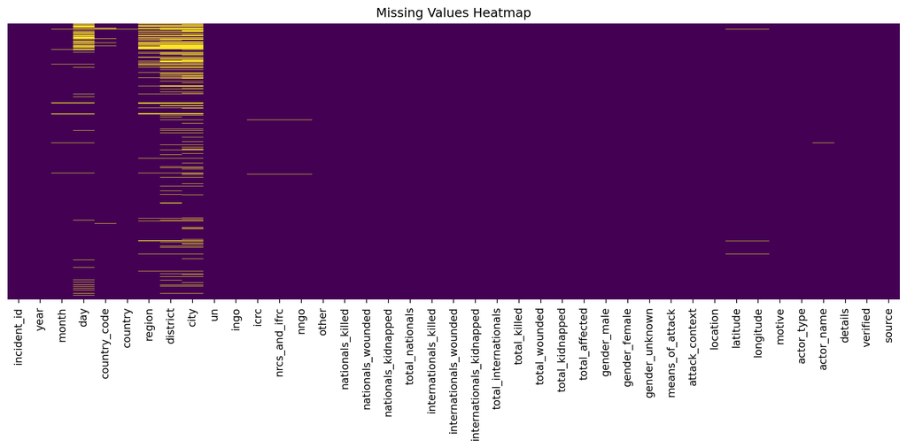

```python
missing_values = df.isnull().sum()
missing_percent = (missing_values / len(df) * 100).round(2)

missing_df = pd.DataFrame({
    'Missing Values': missing_values,
    'Percentage': missing_percent
})

print("Columns with missing values:")
missing_df[missing_df['Missing Values'] > 0].sort_values('Missing Values', ascending=False)

if missing_values.sum() > 0:
    plt.figure(figsize=(12, 6))
    sns.heatmap(df.isnull(), cbar=False, cmap='viridis', yticklabels=False)
    plt.title('Missing Values Heatmap')
    plt.tight_layout()
    plt.show()
```

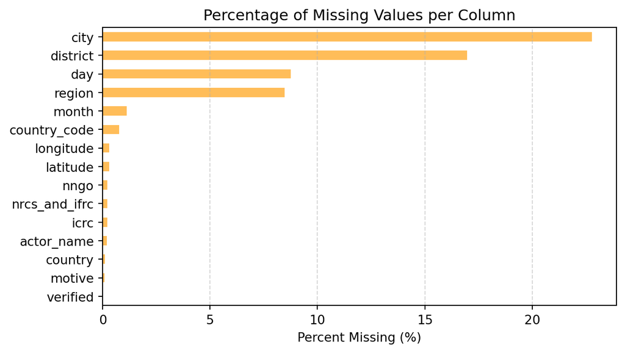

```python
missing_percent = (df.isna().sum() / len(df)) * 100
missing_percent = missing_percent[missing_percent > 0].sort_values(ascending=True)

plt.figure(figsize=(7, 4))
missing_percent.plot(kind='barh', color='#FFBD59')
plt.title("Percentage of Missing Values per Column")
plt.xlabel("Percent Missing (%)")
plt.tight_layout()
plt.grid(axis='x', linestyle='--', alpha=0.5)
plt.show()
```

### 3.1 Strategy for Missing Values

Based on our exploration, we have identified several columns with high proportions of missing values:

- `City` (over 20% missing)
- `District`, `Day`, and `Region` (significant proportions missing)

Since our analysis focus is on broad trends by country, year, and organization type, we will:

1. Remove granular fields with limited analytical value for our specific goals
2. Leave the remaining minimal missing values as-is, as they’re sparse and likely random

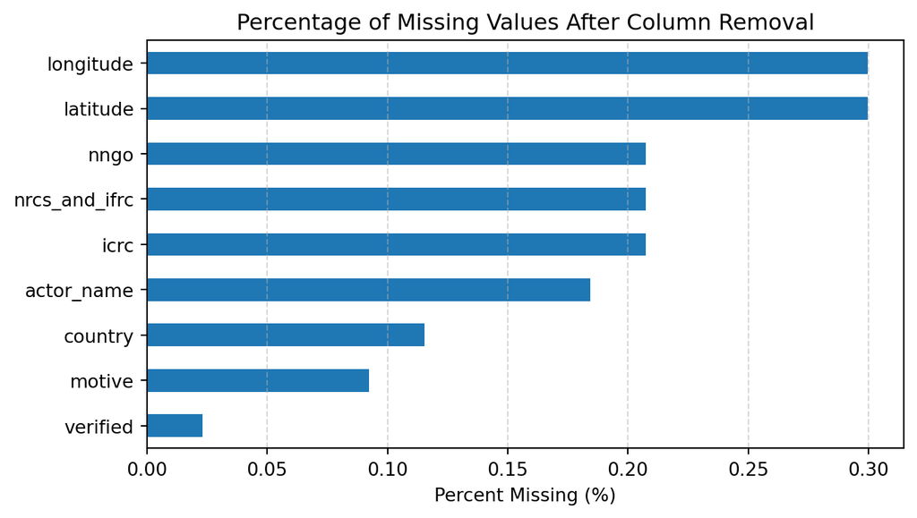

```python
columns_to_drop = ['day', 'month', 'district', 'city', 'region', 'country_code', 'incident_id']
df.drop(columns=columns_to_drop, inplace=True)

# Recalculate missing values after dropping columns
missing_percent = (df.isna().sum() / len(df)) * 100
missing_percent = missing_percent[missing_percent > 0].sort_values(ascending=True)

# Visualize the remaining missing values
plt.figure(figsize=(7, 4))
missing_percent.plot(kind='barh')
plt.title("Percentage of Missing Values After Column Removal")
plt.xlabel("Percent Missing (%)")
plt.tight_layout()
plt.grid(axis='x', linestyle='--', alpha=0.5)
plt.show()
```

```
Columns with missing values:
```

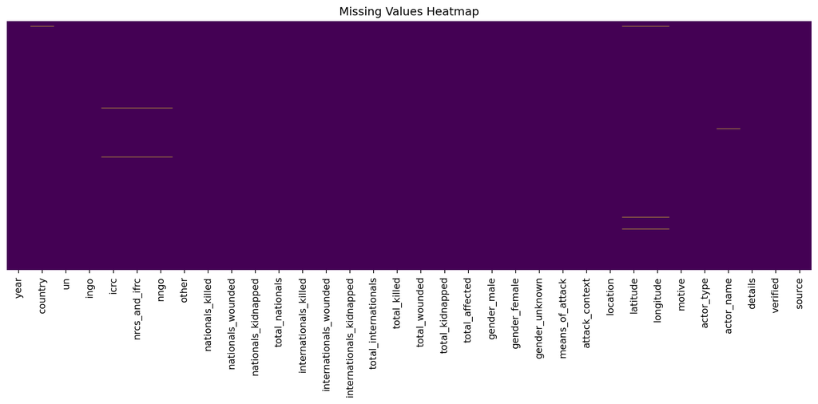

```python
missing_values = df.isnull().sum()
missing_percent = (missing_values / len(df) * 100).round(2)

missing_df = pd.DataFrame({
    'Missing Values': missing_values,
    'Percentage': missing_percent
})

print("Columns with missing values:")
missing_df[missing_df['Missing Values'] > 0].sort_values('Missing Values', ascending=False)

# Visualize missing values if any exist
if missing_values.sum() > 0:
    plt.figure(figsize=(12, 6))
    sns.heatmap(df.isnull(), cbar=False, cmap='viridis', yticklabels=False)
    plt.title('Missing Values Heatmap')
    plt.tight_layout()
    plt.show()
```

### 3.2 Missing Values Decision

Since the highest missing value percentage is now less than 0.5%, and the remaining missing data is sparse, likely random, and not concentrated in critical columns, we’ve decided:

## 4. Handling Duplicates

Let’s identify and remove duplicate records that could skew our analysis.

```python
duplicated_mask = df.duplicated(keep=False)
duplicates = df[duplicated_mask]

duplicate_count = len(duplicates)
print(f"Total number of duplicated rows: {duplicate_count}")

duplicate_patterns = df[duplicated_mask].groupby(df.columns.tolist()).size().reset_index()
duplicate_patterns = duplicate_patterns.rename(columns={0: 'occurrence_count'})

duplicate_patterns = duplicate_patterns.sort_values('occurrence_count', ascending=False)

unique_duplicate_patterns = len(duplicate_patterns)
print(f"Number of unique duplicate patterns: {unique_duplicate_patterns}")

occurrence_summary = duplicate_patterns['occurrence_count'].value_counts().sort_index()
print("\nOccurrence pattern summary:")
for count, frequency in occurrence_summary.items():
    print(f"  {frequency} record(s) appear {count} times each")
```

```
Total number of duplicated rows: 28
Number of unique duplicate patterns: 5

Occurrence pattern summary:
  3 record(s) appear 2 times each
  1 record(s) appear 9 times each
  1 record(s) appear 13 times each
```

Based on the duplicate analysis results, we need to remove duplicates from the dataset. The pattern of duplications (with some records appearing up to 13 times) suggests systematic duplication issues that could significantly skew our analysis.

```python
original_count = len(df)

df = df.drop_duplicates()

removed_count = original_count - len(df)
removal_percentage = (removed_count / original_count) * 100

print(f"Removed {removed_count} duplicate rows ({removal_percentage:.2f}% of dataset)")
print(f"Dataset now contains {len(df)} unique records")
```

```
Removed 23 duplicate rows (0.53% of dataset)
Dataset now contains 4314 unique records
```

## 5. Data Type Optimization

Most data types in this dataset are appropriate, but there are a few minor adjustments that could be made for consistency:

```python
df.dtypes
```

```
year                          int64
country                      object
un                            int64
ingo                          int64
icrc                        float64
nrcs_and_ifrc               float64
nngo                        float64
other                         int64
nationals_killed              int64
nationals_wounded             int64
nationals_kidnapped           int64
total_nationals               int64
internationals_killed         int64
internationals_wounded        int64
internationals_kidnapped      int64
total_internationals          int64
total_killed                  int64
total_wounded                 int64
total_kidnapped               int64
total_affected                int64
gender_male                   int64
gender_female                 int64
gender_unknown                int64
means_of_attack              object
attack_context               object
location                     object
latitude                    float64
longitude                   float64
motive                       object
actor_type                   object
actor_name                   object
details                      object
verified                     object
source                       object
dtype: object
```

### 5.1 Data Type Conversion

The following columns could benefit from data type conversion:

| Column | Current | Suggested | Reason |
| --- | --- | --- | --- |
| `icrc` | float64 | int64 | Counts should be integers |
| `nrcs_and_ifrc` | float64 | int64 | Counts should be integers |
| `nngo` | float64 | int64 | Counts should be integers |

```python
count_columns = ['icrc', 'nrcs_and_ifrc', 'nngo']
for col in count_columns:
    if col in df.columns:
        df[col] = df[col].fillna(0).astype(int)

df[count_columns].dtypes
```

```
icrc             int64
nrcs_and_ifrc    int64
nngo             int64
dtype: object
```

## 6. Outlier Analysis and Handling

Let’s identify and visualize outliers in the dataset to better understand extreme values in our security incidents data.

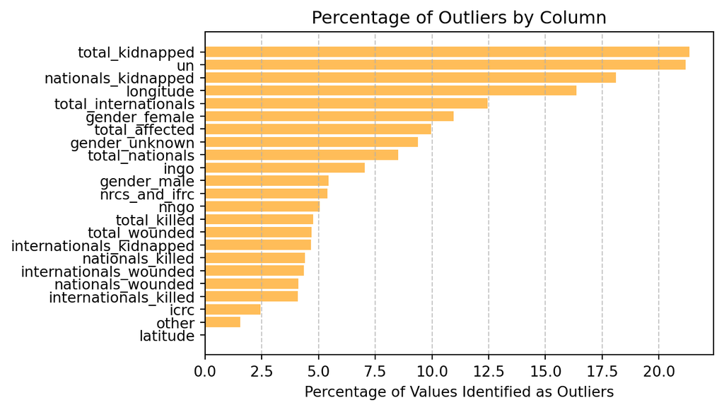

```python
import warnings
warnings.filterwarnings('ignore', category=FutureWarning)
# Function to detect outliers using IQR method
def detect_outliers(df, column):
    q1 = df[column].quantile(0.25)
    q3 = df[column].quantile(0.75)
    iqr = q3 - q1
    lower_bound = q1 - 1.5 * iqr
    upper_bound = q3 + 1.5 * iqr

    outliers = df[(df[column] < lower_bound) | (df[column] > upper_bound)]
    return outliers, lower_bound, upper_bound

excluded_cols = ['year']
numeric_cols = df.select_dtypes(include=['int64', 'float64']).columns
numeric_cols = [col for col in numeric_cols if col not in excluded_cols]

outlier_summary = pd.DataFrame(columns=['Column', 'Total', 'Outliers', 'Percentage'])

for col in numeric_cols:
    outliers, _, _ = detect_outliers(df, col)

    new_row = {
        'Column': col,
        'Total': len(df),
        'Outliers': len(outliers),
        'Percentage': len(outliers) / len(df) * 100
    }
    outlier_summary = pd.concat([outlier_summary, pd.DataFrame([new_row])], ignore_index=True)

outlier_summary = outlier_summary.sort_values('Percentage', ascending=True)

plt.figure(figsize=(7,4))
plt.barh(outlier_summary['Column'], outlier_summary['Percentage'], color='#FFBD59')
plt.title('Percentage of Outliers by Column')
plt.xlabel('Percentage of Values Identified as Outliers')
plt.grid(axis='x', linestyle='--', alpha=0.7)
plt.tight_layout()
plt.show()
```

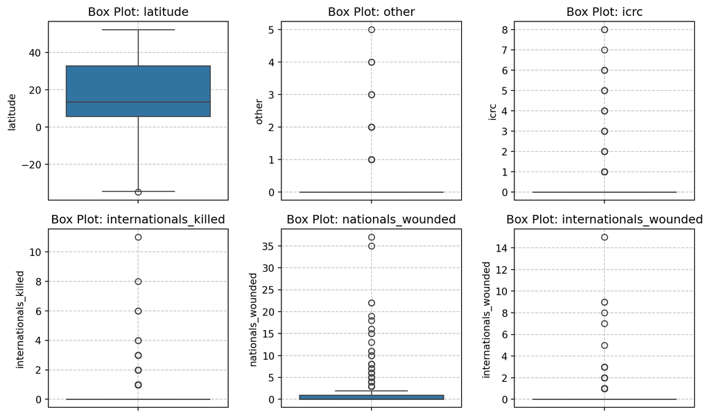

```python
top_cols = outlier_summary.head(6)['Column'].tolist()

# Create boxplots for top outlier columns
plt.figure(figsize=(10, 6))
for i, col in enumerate(top_cols, 1):
    plt.subplot(2, 3, i)
    sns.boxplot(y=df[col])
    plt.title(f'Box Plot: {col}')
    plt.grid(linestyle='--', alpha=0.7)
plt.tight_layout()
plt.show()
```

### 6.2 Outlier Handling Strategy

In security incident data, outliers often represent real extreme events (like major attacks) rather than errors. For our analysis:

1. We’ll flag high-impact incidents rather than removing them
2. This allows us to analyze with or without extreme events as needed

```python
df['high_impact'] = False

for col in ['total_killed', 'total_wounded', 'total_kidnapped', 'total_affected']:
    if col in df.columns:
        threshold = df[col].quantile(0.99)
        df.loc[df[col] > threshold, 'high_impact'] = True

high_impact_count = df['high_impact'].sum()
print(f"Flagged {high_impact_count} high-impact incidents ({high_impact_count/len(df)*100:.2f}% of dataset)")

if 'total_affected' in df.columns:
    print("\nTop 5 most severe incidents:")
    display(df.sort_values('total_affected', ascending=False).head(5)[
        ['year', 'country', 'total_affected', 'total_killed', 'total_wounded', 'total_kidnapped']])
```

```
Flagged 123 high-impact incidents (2.85% of dataset)

Top 5 most severe incidents:
```

|  | year | country | total_affected | total_killed | total_wounded | total_kidnapped |
| --- | --- | --- | --- | --- | --- | --- |
| 3857 | 2023 | Occupied Palestinian Territories | 92 | 70 | 22 | 0 |
| 1989 | 2015 | Afghanistan | 49 | 14 | 35 | 0 |
| 3920 | 2023 | Occupied Palestinian Territories | 46 | 41 | 5 | 0 |
| 1189 | 2011 | Nigeria | 46 | 9 | 37 | 0 |
| 3936 | 2023 | Occupied Palestinian Territories | 31 | 31 | 0 | 0 |

## 7. Geographic Data Validation

Let’s verify that our latitude and longitude values are within valid ranges.

```
Invalid latitude values (outside -90 to 90): 0
Invalid longitude values (outside -180 to 180): 0

Latitude range: -34.883611 to 52.253183
Longitude range: -102.283333 to 179.0122737
```

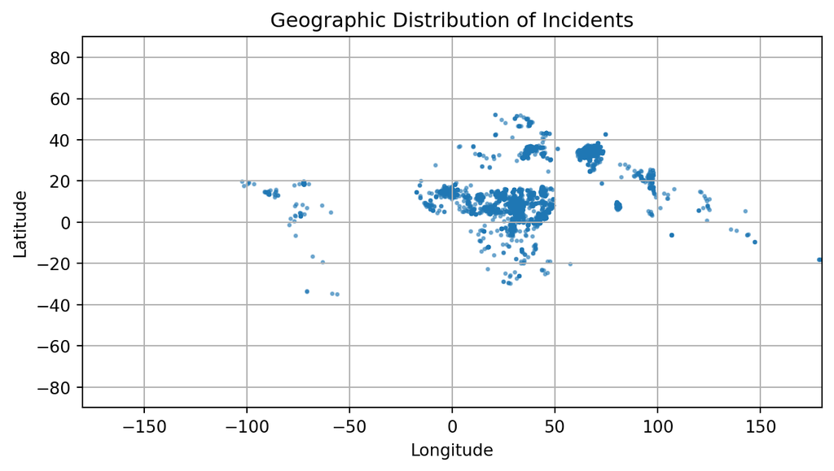

```python
# Check if latitude and longitude values are within valid ranges
# Valid ranges: Latitude (-90 to 90), Longitude (-180 to 180)

invalid_lat = df[(df['latitude'] < -90) | (df['latitude'] > 90)].shape[0]
invalid_lon = df[(df['longitude'] < -180) | (df['longitude'] > 180)].shape[0]

print(f"Invalid latitude values (outside -90 to 90): {invalid_lat}")
print(f"Invalid longitude values (outside -180 to 180): {invalid_lon}")

lat_min, lat_max = df['latitude'].min(), df['latitude'].max()
lon_min, lon_max = df['longitude'].min(), df['longitude'].max()

print(f"\nLatitude range: {lat_min} to {lat_max}")
print(f"Longitude range: {lon_min} to {lon_max}")

plt.figure(figsize=(7,4))
plt.scatter(df['longitude'], df['latitude'], alpha=0.5, s=3)
plt.title('Geographic Distribution of Incidents')
plt.xlabel('Longitude')
plt.ylabel('Latitude')
plt.xlim(-180, 180)
plt.ylim(-90, 90)
plt.grid(True)
plt.tight_layout()
plt.show()
```

There are 0 invalid latitudes and longitudes, so we do not have to handle those outliers. All geographic coordinates are within valid ranges and suitable for mapping and spatial analysis.

## 8. Final Dataset Summary

Let’s examine our cleaned dataset:

```python
print(f"Final dataset shape: {df.shape}")
print("\nColumns in the cleaned dataset:")
print(df.columns.tolist())
print("\nSummary statistics:")
df.describe()
```

[output not shown]

|  | year | un | ingo | icrc | nrcs_and_ifrc | nngo | other | nationals_killed | nationals_wounded | nationals_kidnapped | ... | total_internationals | total_killed | total_wounded | total_kidnapped | total_affected | gender_male | gender_female | gender_unknown | latitude | longitude |
| --- | --- | --- | --- | --- | --- | --- | --- | --- | --- | --- | --- | --- | --- | --- | --- | --- | --- | --- | --- | --- | --- |
| count | 4314.000000 | 4314.000000 | 4314.000000 | 4314.000000 | 4314.000000 | 4314.000000 | 4314.000000 | 4314.000000 | 4314.000000 | 4314.000000 | ... | 4314.000000 | 4314.000000 | 4314.000000 | 4314.000000 | 4314.000000 | 4314.000000 | 4314.000000 | 4314.000000 | 4301.000000 | 4301.000000 |
| mean | 2015.245712 | 0.411683 | 0.812471 | 0.051229 | 0.116365 | 0.476124 | 0.024339 | 0.645109 | 0.631433 | 0.410987 | ... | 0.204682 | 0.701205 | 0.695874 | 0.495132 | 1.892211 | 0.894529 | 0.139314 | 0.857904 | 16.693709 | 36.486580 |
| std | 6.804200 | 2.107963 | 1.651766 | 0.420239 | 0.780231 | 1.192180 | 0.224018 | 1.772060 | 1.464470 | 1.242489 | ... | 0.772268 | 1.818565 | 1.517728 | 1.366215 | 2.665913 | 1.217483 | 0.471608 | 2.531503 | 14.481132 | 30.046441 |
| min | 1997.000000 | 0.000000 | 0.000000 | 0.000000 | 0.000000 | 0.000000 | 0.000000 | 0.000000 | 0.000000 | 0.000000 | ... | 0.000000 | 0.000000 | 0.000000 | 0.000000 | 0.000000 | 0.000000 | 0.000000 | 0.000000 | -34.883611 | -102.283333 |
| 25% | 2010.000000 | 0.000000 | 0.000000 | 0.000000 | 0.000000 | 0.000000 | 0.000000 | 0.000000 | 0.000000 | 0.000000 | ... | 0.000000 | 0.000000 | 0.000000 | 0.000000 | 1.000000 | 0.000000 | 0.000000 | 0.000000 | 5.835800 | 28.729977 |
| 50% | 2016.000000 | 0.000000 | 0.000000 | 0.000000 | 0.000000 | 0.000000 | 0.000000 | 0.000000 | 0.000000 | 0.000000 | ... | 0.000000 | 0.000000 | 0.000000 | 0.000000 | 1.000000 | 1.000000 | 0.000000 | 0.000000 | 13.426301 | 34.450000 |
| 75% | 2021.000000 | 0.000000 | 1.000000 | 0.000000 | 0.000000 | 1.000000 | 0.000000 | 1.000000 | 1.000000 | 0.000000 | ... | 0.000000 | 1.000000 | 1.000000 | 0.000000 | 2.000000 | 1.000000 | 0.000000 | 1.000000 | 32.887222 | 45.400000 |
| max | 2025.000000 | 92.000000 | 49.000000 | 8.000000 | 19.000000 | 15.000000 | 5.000000 | 70.000000 | 37.000000 | 19.000000 | ... | 15.000000 | 70.000000 | 37.000000 | 20.000000 | 92.000000 | 17.000000 | 7.000000 | 92.000000 | 52.253183 | 179.012274 |

8 rows × 24 columns

## 9. Conclusion

The dataset is now ready for exploratory data analysis and modeling to identify trends in aid worker security incidents by country, year, and organization type.

```python
df.to_csv("data/security_incidents_cleaned.csv", index=False)
```